# One4All_LA5

Braden Griebel, Luke Fanning, Ahyo Falick, Andrew Duffy

2019-29-9

```r
# Load tidyverse
library(tidyverse)

# Load and view the data
milk <- read.csv('state_milk_production.csv')
head(milk)
```

```
##      region         state year milk_produced
## 1 Northeast         Maine 1970      6.19e+08
## 2 Northeast New Hampshire 1970      3.56e+08
## 3 Northeast       Vermont 1970      1.97e+09
## 4 Northeast Massachusetts 1970      6.58e+08
## 5 Northeast  Rhode Island 1970      7.50e+07
## 6 Northeast   Connecticut 1970      6.61e+08
```

```r
milk<-milk%>%mutate(milk_million=milk_produced/1000000)
```

## Milk production across states our group has lived in

```r
states<-c("Colorado", "New Jersey","Massachusetts", "Utah", "Washington", "California","Maryland")
```

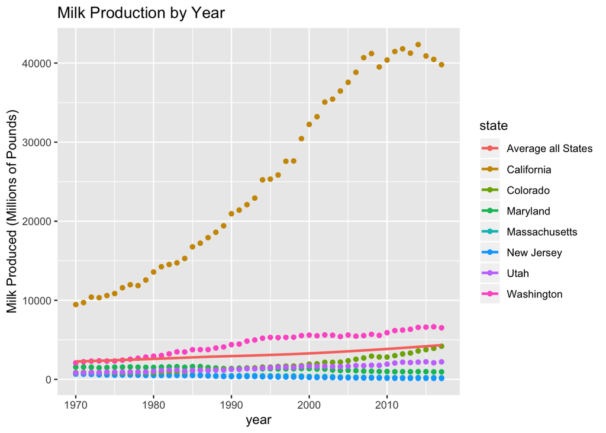

```r
milk_mod<-milk%>%mutate(milk_million=milk_produced/1000000)
milk_states<- milk_mod %>% filter(state %in% states)
milk_sum <- milk_mod%>% group_by(year)%>% summarise(milk_average=mean(milk_million))
ggplot()+geom_point(data=milk_states,aes(x=year,y=milk_million,color=state))+
  geom_smooth(data=milk_sum,mapping=aes(x=year,y=milk_average,color="Average all States"),se=FALSE)+
  labs(xlab="Year",y="Milk Produced (Millions of Pounds)",title="Milk Production by Year")
```

This plot shows a clear difference between California’s milk production and every other state shown above, with California having by far the most milk production compared to any of the other states. This can also be seen by the average across all of the states, as California produced much much more milk than the average across all of the years shown. This plot also shows a clear upwards trend in milk production across most states as time goes on, displaying the growing demand for milk that comes with a growing population and growing US exports of milk to other countries.

```r
milk_by_year<-milk_mod%>%group_by(year)%>%summarise(milk_total_million=sum(milk_million))%>%
  arrange(milk_total_million)
```

## The year in which the most milk was produced

```r
milk_by_year[length(milk_by_year$year),]
```

```
## # A tibble: 1 x 2
##    year milk_total_million
##   <dbl>              <dbl>
## 1  2017             215466
```

## The year in which the least milk was produced

```r
milk_by_year[1,]
```

```
## # A tibble: 1 x 2
##    year milk_total_million
##   <dbl>              <dbl>
## 1  1975             115398
```

## The top 5 and bottom 5 milk producers in 2017 by state

```r
milk2017<-milk_mod%>%filter(year==2017)
milk2017_bottom<-milk2017%>%group_by(state)%>%summarise(milk_produced=milk_million)%>%
  filter(rank(milk_produced)<=5)%>%arrange(desc(milk_produced))
milk2017_top<-milk2017%>%group_by(state)%>%summarise(milk_produced=milk_million)%>%
  filter(rank(desc(milk_produced))<=5)%>%arrange(desc(milk_produced))
```

## Top 5 milk producers in 2017

```r
milk2017_top
```

```
## # A tibble: 5 x 2
##   state      milk_produced
##   <fct>              <dbl>
## 1 California         39798
## 2 Wisconsin          30320
## 3 New York           14912
## 4 Idaho              14627
## 5 Texas              12054
```

## Bottom 5 milk producers in 2017

```r
milk2017_bottom
```

```
## # A tibble: 5 x 2
##   state        milk_produced
##   <fct>                <dbl>
## 1 Alabama                 89
## 2 Arkansas                79
## 3 Hawaii                  39
## 4 Rhode Island            13
## 5 Alaska                   3
```

## Final Discussion

*Luke Fanning:* I found the in class activities relating to DIA incredibly helpful in learning how to perfomr tasks related to this data. I also found that this data allowed us to use a large amount of dplyr functions, which personally helped me gain a deeper understanding of how each one worked and allowed me to better understand how the functions connect to each other and work together. In my individual section, I separated the data down to 1997 milk production, created a new variable that represented the milk production in millions of pounds, and then used a geom_col function to display the data. I reordered the states by the variable I created, and then graphed them against each other while flipping the axes to better display the labels for each state. Finally, I added labels, reduced the font size along the y axis, and added fill and color options to better differentiate each states individual milk production

*Braden Griebel:* First I filtered the data down to my birth year, and then I used the milk_million column to display the milk production by state, both in a table and a graph (using the geom_col function in ggplot). I reordered the graph so it was easier to read. Also, I rotated the axis, and decreased the text size so that it was actually possible to read the labels. Additionally, in the team section I used dplyr to first filter down the data to out states and graph them over the years using ggplot. I also grouped the whole data set by year, and then added a new column for the average milk production in order to graph the average across all 50 states. Adding it to the already existing legend to make it clear what the line meant.

## Ethics Discussion

We believe that the most beneficial use of this data would be for larger milk production companies, as many can see firstly which states are most successful at producing milk (and therefore have the most productive space available for cows), and secondly which areas lack milk production of their own in order to expand markets for shipping in those regions. However, this does have a downside of hurting smaller farmers and ranchers in these lower production states, as with expanded shipping from larger companies, it will much harder for ranchers in Alaska to produce milk at all without being undercut by larger competition.

# Individual Section

## Braden Griebel

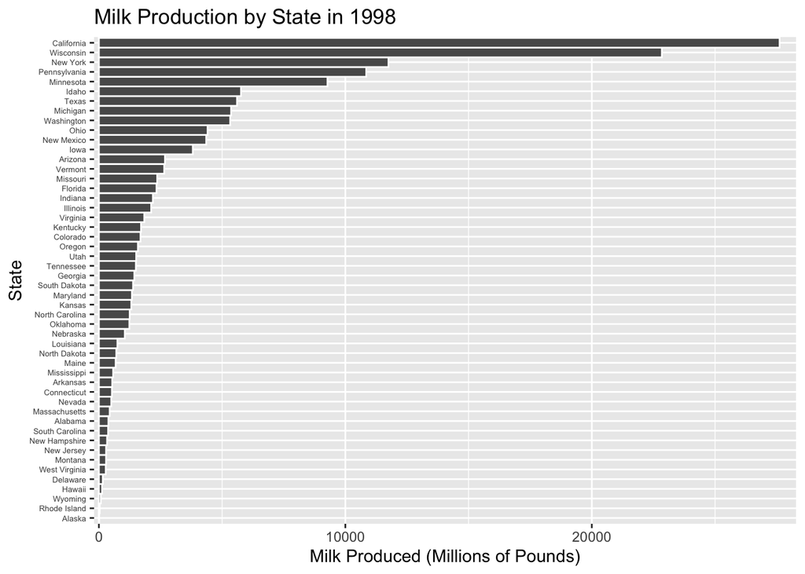

```r
milk %>% filter(year==1998) %>%
  ggplot(aes(x=reorder(state,milk_million,FUN=identity),y=milk_million))+geom_col(width=1,color="white")+coord_flip(ylim=c(1100,27000))+labs(y="Milk Produced (Millions of Pounds)",x="State", title="Milk Production by State in 1998")+ theme( axis.text.y = element_text(size=5))
```

```r
milk%>%filter(year==1998)%>% group_by(state)%>% summarise(milk_million=milk_million)%>%arrange(desc(milk_million))%>%as_tibble()%>%print()
```

```
## # A tibble: 50 x 2
##    state        milk_million
##    <fct>               <dbl>
##  1 California          27620
##  2 Wisconsin           22842
##  3 New York            11750
##  4 Pennsylvania        10847
##  5 Minnesota            9275
##  6 Idaho                5765
##  7 Texas                5605
##  8 Michigan             5365
##  9 Washington           5326
## 10 Ohio                 4410
## # … with 40 more rows
```

### Summary of Milk Production for My Birth Year (1998)

```r
milk%>% filter(year==1998) %>% mutate(milk_million=milk_produced/1000000)%>%group_by(year)%>%summarize(average=mean(milk_million),median=median(milk_million))%>%as_tibble()%>%print()
```

```
## # A tibble: 1 x 3
##    year average median
##   <dbl>   <dbl>  <dbl>
## 1  1998   3145.  1412.
```

```r
milk_ordered<-milk%>% filter(year==1998) %>% mutate(milk_million=milk_produced/1000000)%>%group_by(state)%>%arrange(milk_million)
```

### State that Produced the Least milk

```r
milk_ordered[1,c(2,5)]
```

```
## # A tibble: 1 x 2
## # Groups:   state [1]
##   state  milk_million
##   <fct>         <dbl>
## 1 Alaska           14
```

### State that Produced the most milk

```r
milk_ordered[length(milk_ordered$state),c(2,5)]
```

```
## # A tibble: 1 x 2
## # Groups:   state [1]
##   state      milk_million
##   <fct>             <dbl>
## 1 California        27620
```

## Ahyo Falick

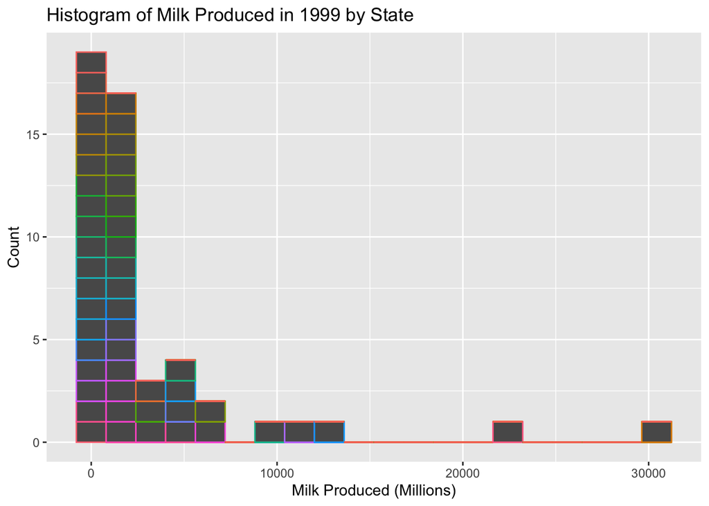

```r
milk %>% mutate(mm=(milk_produced/1000000)) %>% filter(year==1999) %>% ggplot(aes(x = mm, color = state)) +
  geom_histogram(bins = 20) + theme(legend.position = "none") +
  labs(title = "Histogram of Milk Produced in 1999 by State", y = "Count", x = "Milk Produced (Millions)")
```

### Summary of Average Milk Production by State in 1999

```r
milk %>% mutate(mm = milk_produced/1000000) %>% filter(year == 1999) %>% group_by(state) %>% summarize(average=mean(mm),median=median(mm))%>%as_tibble()%>%print()
```

```
## # A tibble: 50 x 3
##    state       average median
##    <fct>         <dbl>  <dbl>
##  1 Alabama         376    376
##  2 Alaska           14     14
##  3 Arizona        2931   2931
##  4 Arkansas        520    520
##  5 California    30444  30444
##  6 Colorado       1728   1728
##  7 Connecticut     520    520
##  8 Delaware        145    145
##  9 Florida        2398   2398
## 10 Georgia        1449   1449
## # … with 40 more rows
```

### State That Produced the Most Amount of Milk

```r
milk %>% filter(year == 1999) %>% arrange(desc(milk_million)) %>% filter(state == "California")
```

```
##    region      state year milk_produced milk_million
## 1 Pacific California 1999    3.0444e+10        30444
```

### State That Produced the Least Amount of Milk

```r
milk %>% filter(year == 1999) %>% arrange(desc(milk_million)) %>% filter(state == "Alaska")
```

```
##    region  state year milk_produced milk_million
## 1 Pacific Alaska 1999       1.4e+07           14
```

## Luke Fanning

### Distribution of milk production in 1997

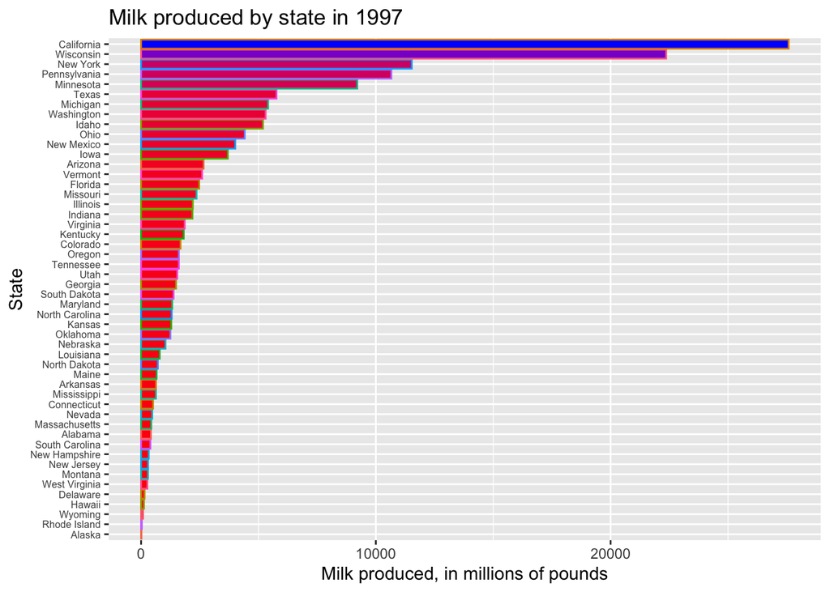

```r
milk %>% filter(year == 1997) %>%  mutate(milk_millions=(milk_produced/1000000)) %>% group_by(state) %>% arrange(milk_millions) %>% ggplot(mapping = aes(x=reorder(state,milk_millions), y=milk_millions, fill = milk_millions, color = state)) + geom_col() + coord_flip() + scale_fill_gradient( low = "red", high = "blue") +  labs(x= "State", y = "Milk produced, in millions of pounds", title = "Milk produced by state in 1997") + theme(legend.position = "none", axis.text.y = element_text(size=6))
```

### Average Milk production by state in 1997

```r
milk %>% filter(year == 1997) %>% mutate(milk_millions=(milk_produced/1000000)) %>% summarize (mean(milk_millions), median(milk_millions))
```

```
##   mean(milk_millions) median(milk_millions)
## 1             3121.82                  1436
```

As seen from the data above, the average milk produced per state in 1997 was 3121.82 million pounds of milk and the median amount of milk produced was 1436 million pounds of milk.

### State that produced the most milk in 1997

```r
milk %>% filter(year == 1997) %>% mutate(milk_millions=(milk_produced/1000000)) %>% group_by(state) %>% summarise(milk_produced_millions=max(milk_millions)) %>% arrange(desc(milk_produced_millions))
```

```
## # A tibble: 50 x 2
##    state        milk_produced_millions
##    <fct>                         <dbl>
##  1 California                    27582
##  2 Wisconsin                     22368
##  3 New York                      11530
##  4 Pennsylvania                  10662
##  5 Minnesota                      9210
##  6 Texas                          5768
##  7 Michigan                       5410
##  8 Washington                     5305
##  9 Idaho                          5193
## 10 Ohio                           4415
## # … with 40 more rows
```

As seen from the data above, California produced the most milk in 1997, producing 27,582 million pounds.

### State that produced the least milk in 1997

```r
milk %>% filter(year == 1997) %>% mutate(milk_millions=(milk_produced/1000000)) %>% group_by(state) %>% summarise(milk_produced_millions=max(milk_millions)) %>% arrange(milk_produced_millions)
```

```
## # A tibble: 50 x 2
##    state          milk_produced_millions
##    <fct>                           <dbl>
##  1 Alaska                             15
##  2 Rhode Island                       32
##  3 Wyoming                            84
##  4 Hawaii                            123
##  5 Delaware                          148
##  6 West Virginia                     266
##  7 Montana                           295
##  8 New Jersey                        299
##  9 New Hampshire                     328
## 10 South Carolina                    397
## # … with 40 more rows
```

As seen from the data above, Alaska produced the least amount of milk in 1997, producing 15 million pounds.

## Andrew Duffy

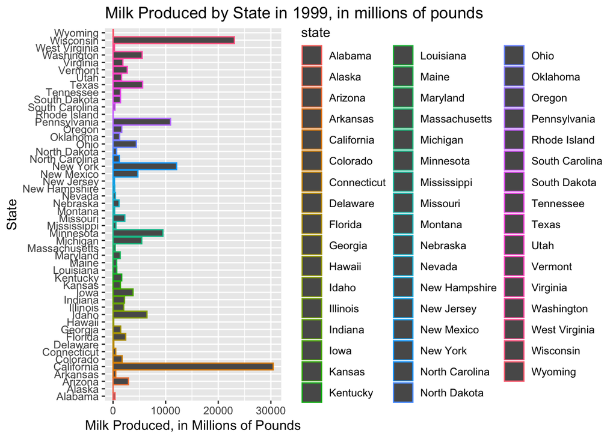

### State that produced the most milk in 1999

```
## # A tibble: 50 x 2
##    state        most_milk
##    <fct>            <dbl>
##  1 California       30444
##  2 Wisconsin        23071
##  3 New York         12082
##  4 Pennsylvania     10931
##  5 Minnesota         9478
##  6 Idaho             6453
##  7 Texas             5620
##  8 Washington        5535
##  9 Michigan          5455
## 10 New Mexico        4724
## # … with 40 more rows
```

### State that produced the least milk in 1999

```
## # A tibble: 50 x 2
##    state          least_milk
##    <fct>               <dbl>
##  1 Alaska                 14
##  2 Rhode Island           31
##  3 Wyoming                80
##  4 Hawaii                120
##  5 Delaware              145
##  6 West Virginia         275
##  7 New Jersey            280
##  8 Montana               303
##  9 New Hampshire         321
## 10 South Carolina        369
## # … with 40 more rows
```

# One4All_LA5

Braden Griebel, Luke Fanning, Ahyo Falick, Andrew Duffy

2019-29-9

```r
# Load tidyverse
library(tidyverse)

# Load and view the data
milk <- read.csv('state_milk_production.csv')
head(milk)
```

```
##      region         state year milk_produced
## 1 Northeast         Maine 1970      6.19e+08
## 2 Northeast New Hampshire 1970      3.56e+08
## 3 Northeast       Vermont 1970      1.97e+09
## 4 Northeast Massachusetts 1970      6.58e+08
## 5 Northeast  Rhode Island 1970      7.50e+07
## 6 Northeast   Connecticut 1970      6.61e+08
```

```r
milk<-milk%>%mutate(milk_million=milk_produced/1000000)
```

## Milk production across states our group has lived in

```r
states<-c("Colorado", "New Jersey","Massachusetts", "Utah", "Washington", "California","Maryland")
```

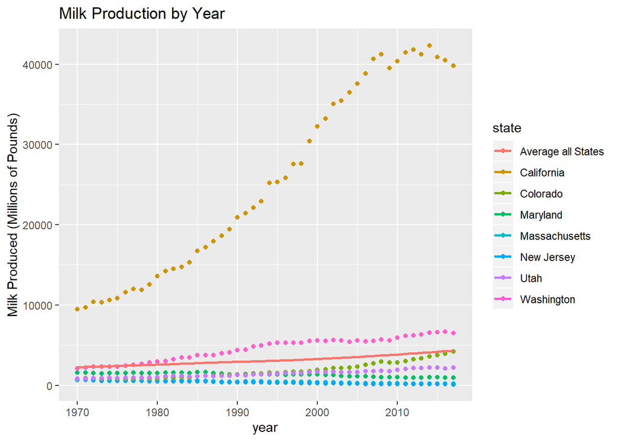

```r
milk_mod<-milk%>%mutate(milk_million=milk_produced/1000000)
milk_states<- milk_mod %>% filter(state %in% states)
milk_sum <- milk_mod%>% group_by(year)%>% summarise(milk_average=mean(milk_million))
ggplot()+geom_point(data=milk_states,aes(x=year,y=milk_million,color=state))+
  geom_smooth(data=milk_sum,mapping=aes(x=year,y=milk_average,color="Average all States"),se=FALSE)+
  labs(xlab="Year",y="Milk Produced (Millions of Pounds)",title="Milk Production by Year")
```

This plot shows a clear difference between California’s milk production and every other state shown above, with California having by far the most milk production compared to any of the other states. This can also be seen by the average across all of the states, as California produced much much more milk than the average across all of the years shown. This plot also shows a clear upwards trend in milk production across most states as time goes on, displaying the growing demand for milk that comes with a growing population and growing US exports of milk to other countries.

```r
milk_by_year<-milk_mod%>%group_by(year)%>%summarise(milk_total_million=sum(milk_million))%>%
  arrange(milk_total_million)
```

## The year in which the most milk was produced

```r
milk_by_year[length(milk_by_year$year),]
```

```
## # A tibble: 1 x 2
##    year milk_total_million
##   <dbl>              <dbl>
## 1  2017             215466
```

## The year in which the least milk was produced

```r
milk_by_year[1,]
```

```
## # A tibble: 1 x 2
##    year milk_total_million
##   <dbl>              <dbl>
## 1  1975             115398
```

## The top 5 and bottom 5 milk producers in 2017 by state

```r
milk2017<-milk_mod%>%filter(year==2017)
milk2017_bottom<-milk2017%>%group_by(state)%>%summarise(milk_produced=milk_million)%>%
  filter(rank(milk_produced)<=5)%>%arrange(desc(milk_produced))
milk2017_top<-milk2017%>%group_by(state)%>%summarise(milk_produced=milk_million)%>%
  filter(rank(desc(milk_produced))<=5)%>%arrange(desc(milk_produced))
```

## Top 5 milk producers in 2017

```r
milk2017_top
```

```
## # A tibble: 5 x 2
##   state      milk_produced
##   <fct>              <dbl>
## 1 California         39798
## 2 Wisconsin          30320
## 3 New York           14912
## 4 Idaho              14627
## 5 Texas              12054
```

## Bottom 5 milk producers in 2017

```r
milk2017_bottom
```

```
## # A tibble: 5 x 2
##   state        milk_produced
##   <fct>                <dbl>
## 1 Alabama                 89
## 2 Arkansas                79
## 3 Hawaii                  39
## 4 Rhode Island            13
## 5 Alaska                   3
```

## Ethics Discussion

We believe that the most beneficial use of this data would be for larger milk production companies, as many can see firstly which states are most successful at producing milk (and therefore have the most productive space available for cows), and secondly which areas lack milk production of their own in order to expand markets for shipping in those regions. However, this does have a downside of hurting smaller farmers and ranchers in these lower production states, as with expanded shipping from larger companies, it will much harder for ranchers in Alaska to produce milk at all without being undercut by larger competition.

# Individual Section

## Braden Griebel

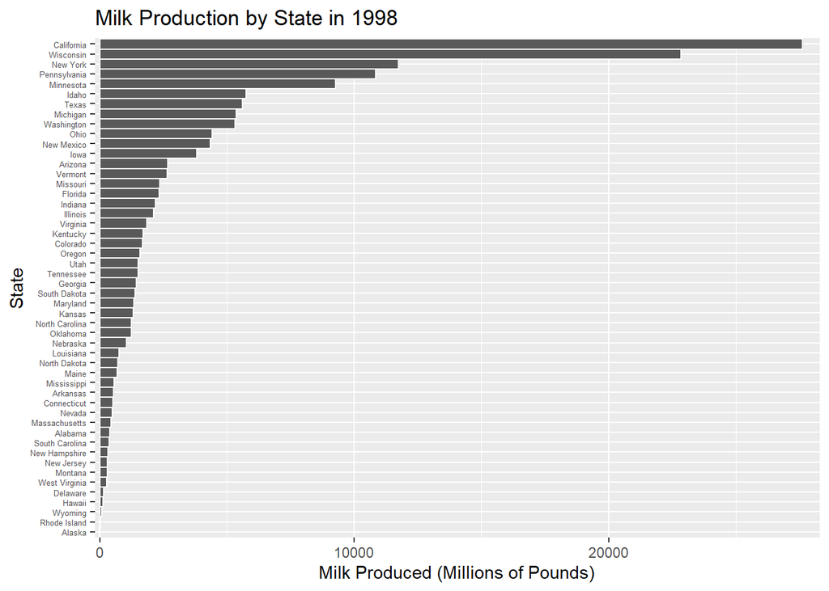

```r
milk %>% filter(year==1998) %>%
  ggplot(aes(x=reorder(state,milk_million,FUN=identity),y=milk_million))+geom_col(width=1,color="white")+coord_flip(ylim=c(1100,27000))+labs(y="Milk Produced (Millions of Pounds)",x="State", title="Milk Production by State in 1998")+ theme( axis.text.y = element_text(size=5))
```

```r
milk%>%filter(year==1998)%>% group_by(state)%>% summarise(milk_million=milk_million)%>%arrange(desc(milk_million))%>%as_tibble()%>%print()
```

```
## # A tibble: 50 x 2
##    state        milk_million
##    <fct>               <dbl>
##  1 California          27620
##  2 Wisconsin           22842
##  3 New York            11750
##  4 Pennsylvania        10847
##  5 Minnesota            9275
##  6 Idaho                5765
##  7 Texas                5605
##  8 Michigan             5365
##  9 Washington           5326
## 10 Ohio                 4410
## # ... with 40 more rows
```

### Summary of Milk Production for My Birth Year (1998)

Average and median across all states

```r
milk%>% filter(year==1998) %>% group_by(year)%>%summarize(average=mean(milk_million),median=median(milk_million))%>%as_tibble()%>%print()
```

```
## # A tibble: 1 x 3
##    year average median
##   <dbl>   <dbl>  <dbl>
## 1  1998   3145.  1412.
```

Average and median for each state during my birthyear, which since its for a single year is just the amount of milk produced by the state

```r
milk%>% filter(year==1998) %>% group_by(state)%>%summarize(average=mean(milk_million),median=median(milk_million))%>%as_tibble()%>%print()
```

```
## # A tibble: 50 x 3
##    state       average median
##    <fct>         <dbl>  <dbl>
##  1 Alabama         386    386
##  2 Alaska           14     14
##  3 Arizona        2680   2680
##  4 Arkansas        540    540
##  5 California    27620  27620
##  6 Colorado       1689   1689
##  7 Connecticut     529    529
##  8 Delaware        159    159
##  9 Florida        2337   2337
## 10 Georgia        1437   1437
## # ... with 40 more rows
```

```r
milk_ordered<-milk%>% filter(year==1998) %>% mutate(milk_million=milk_produced/1000000)%>%group_by(state)%>%arrange(milk_million)
```

### State that Produced the Least milk

```r
milk_ordered[1,c(2,5)]
```

```
## # A tibble: 1 x 2
## # Groups:   state [1]
##   state  milk_million
##   <fct>         <dbl>
## 1 Alaska           14
```

### State that Produced the most milk

```r
milk_ordered[length(milk_ordered$state),c(2,5)]
```

```
## # A tibble: 1 x 2
## # Groups:   state [1]
##   state      milk_million
##   <fct>             <dbl>
## 1 California        27620
```

## Ahyo Falick

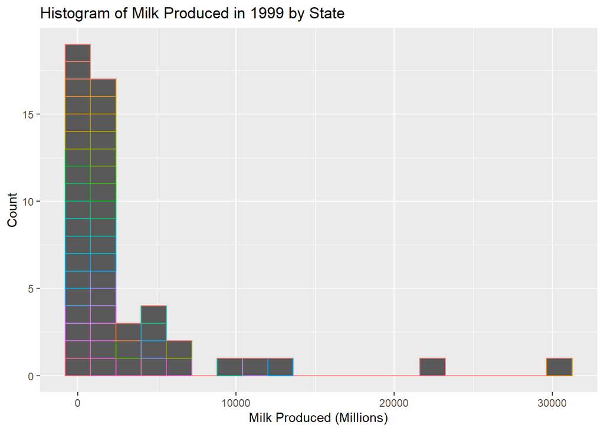

```r
milk %>% mutate(mm=(milk_produced/1000000)) %>% filter(year==1999) %>% ggplot(aes(x = mm, color = state)) +
  geom_histogram(bins = 20) + theme(legend.position = "none") +
  labs(title = "Histogram of Milk Produced in 1999 by State", y = "Count", x = "Milk Produced (Millions)")
```

### Summary of Average Milk Production by State in 1999

```r
milk %>% mutate(mm = milk_produced/1000000) %>% filter(year == 1999) %>% group_by(state) %>% summarize(average=mean(mm),median=median(mm))%>%as_tibble()%>%print()
```

```
## # A tibble: 50 x 3
##    state       average median
##    <fct>         <dbl>  <dbl>
##  1 Alabama         376    376
##  2 Alaska           14     14
##  3 Arizona        2931   2931
##  4 Arkansas        520    520
##  5 California    30444  30444
##  6 Colorado       1728   1728
##  7 Connecticut     520    520
##  8 Delaware        145    145
##  9 Florida        2398   2398
## 10 Georgia        1449   1449
## # ... with 40 more rows
```

### State That Produced the Most Amount of Milk

```r
milk %>% filter(year == 1999) %>% arrange(desc(milk_million)) %>% filter(state == "California")
```

```
##    region      state year milk_produced milk_million
## 1 Pacific California 1999    3.0444e+10        30444
```

### State That Produced the Least Amount of Milk

```r
milk %>% filter(year == 1999) %>% arrange(desc(milk_million)) %>% filter(state == "Alaska")
```

```
##    region  state year milk_produced milk_million
## 1 Pacific Alaska 1999       1.4e+07           14
```

## Luke Fanning

### Distribution of milk production in 1997

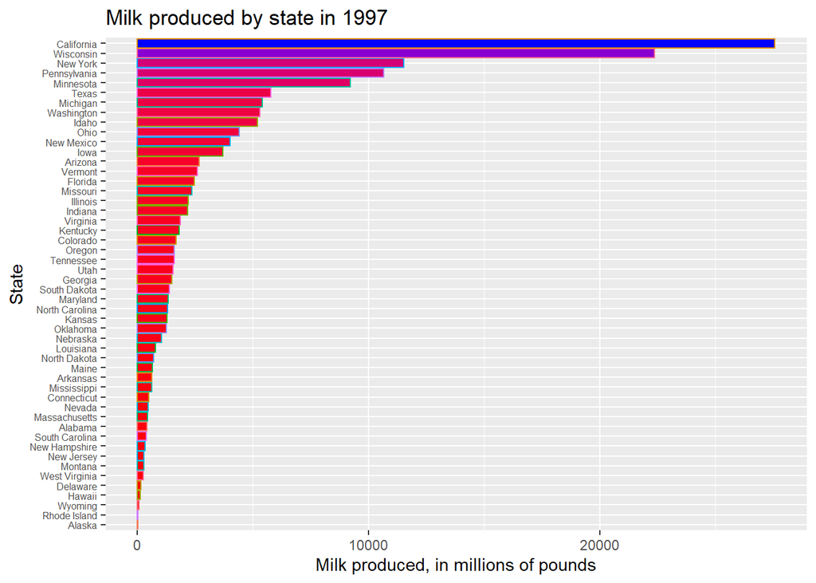

```r
milk %>% filter(year == 1997) %>%  mutate(milk_millions=(milk_produced/1000000)) %>% group_by(state) %>% arrange(milk_millions) %>% ggplot(mapping = aes(x=reorder(state,milk_millions), y=milk_millions, fill = milk_millions, color = state)) + geom_col() + coord_flip() + scale_fill_gradient( low = "red", high = "blue") +  labs(x= "State", y = "Milk produced, in millions of pounds", title = "Milk produced by state in 1997") + theme(legend.position = "none", axis.text.y = element_text(size=6))
```

### Average Milk production by state in 1997

```r
milk %>% filter(year == 1997) %>% mutate(milk_millions=(milk_produced/1000000)) %>% summarize (mean(milk_millions), median(milk_millions))
```

```
##   mean(milk_millions) median(milk_millions)
## 1             3121.82                  1436
```

As seen from the data above, the average milk produced per state in 1997 was 3121.82 million pounds of milk and the median amount of milk produced was 1436 million pounds of milk.

### State that produced the most milk in 1997

```r
milk %>% filter(year == 1997) %>% mutate(milk_millions=(milk_produced/1000000)) %>% group_by(state) %>% summarise(milk_produced_millions=max(milk_millions)) %>% arrange(desc(milk_produced_millions))
```

```
## # A tibble: 50 x 2
##    state        milk_produced_millions
##    <fct>                         <dbl>
##  1 California                    27582
##  2 Wisconsin                     22368
##  3 New York                      11530
##  4 Pennsylvania                  10662
##  5 Minnesota                      9210
##  6 Texas                          5768
##  7 Michigan                       5410
##  8 Washington                     5305
##  9 Idaho                          5193
## 10 Ohio                           4415
## # ... with 40 more rows
```

As seen from the data above, California produced the most milk in 1997, producing 27,582 million pounds.

### State that produced the least milk in 1997

```r
milk %>% filter(year == 1997) %>% mutate(milk_millions=(milk_produced/1000000)) %>% group_by(state) %>% summarise(milk_produced_millions=max(milk_millions)) %>% arrange(milk_produced_millions)
```

```
## # A tibble: 50 x 2
##    state          milk_produced_millions
##    <fct>                           <dbl>
##  1 Alaska                             15
##  2 Rhode Island                       32
##  3 Wyoming                            84
##  4 Hawaii                            123
##  5 Delaware                          148
##  6 West Virginia                     266
##  7 Montana                           295
##  8 New Jersey                        299
##  9 New Hampshire                     328
## 10 South Carolina                    397
## # ... with 40 more rows
```

As seen from the data above, Alaska produced the least amount of milk in 1997, producing 15 million pounds.

# Individual Contributions

*Luke Fanning:* I found the in class activities relating to DIA incredibly helpful in learning how to perfomr tasks related to this data. I also found that this data allowed us to use a large amount of dplyr functions, which personally helped me gain a deeper understanding of how each one worked and allowed me to better understand how the functions connect to each other and work together. In my individual section, I separated the data down to 1997 milk production, created a new variable that represented the milk production in millions of pounds, and then used a geom_col function to display the data. I reordered the states by the variable I created, and then graphed them against each other while flipping the axes to better display the labels for each state. Finally, I added labels, reduced the font size along the y axis, and added fill and color options to better differentiate each states individual milk production

*Braden Griebel:* First I filtered the data down to my birth year, and then I used the milk_million column to display the milk production by state, both in a table and a graph (using the geom_col function in ggplot). I reordered the graph so it was easier to read. Also, I rotated the axis, and decreased the text size so that it was actually possible to read the labels. Additionally, in the team section I used dplyr to first filter down the data to out states and graph them over the years using ggplot. I also grouped the whole data set by year, and then added a new column for the average milk production in order to graph the average across all 50 states. Adding it to the already existing legend to make it clear what the line meant.